# 時系列分析 第 14 回

回帰分析

Kenichiro Tamaki

2022 年 7 月 11 日

# 1 時系列回帰分析

時系列データに対する回帰分析を考える.
$$y_{t} = \alpha + \beta_{1} x_{t, 1} \dots + \beta_{k} x_{t, k} + u_{t}
\quad (t = 1, \dots, T)$$

誤差項に系列相関が存在する場合, 最小二乗推定量の有効性は成り立たない. 特に, 通常の $t$ 統計量, $F$ 統計量, LM 統計量を用いて仮説検定を行うことは妥当でない.

## 1.1 系列相関の検定

誤差項 $u_{t}$ が AR$(1)$ に従う場合は DW (Durbin–Watson) 検定を用いるが, 誤差項が次の AR$(p)$ に従う場合は, Breusch–Godfrey 検定を用いる.
$$u_{t} = \rho_{1} u_{t - 1} + \dots + \rho_{p} u_{t - p} +
\varepsilon_{t}$$

1. 最小二乗法を用いて残差 $\hat{u}_{t}$ を求める
2. 次の回帰式に対して, 最小二乗法を用いて決定係数 $R^{2}$ を求める
   $$\hat{u}_{t} = \gamma_{0} + \gamma_{1} x_{t, 1} + \dots + \gamma_{k}
   x_{t, k} + \rho_{1} \hat{u}_{t - 1} + \dots + \rho_{p} \hat{u}_{t - p} +
   \varepsilon_{t} \quad (t = p + 1, \dots, T)$$
3. 帰無仮説 $H_{0}: \rho_{1} = \dots = \rho_{p} = 0$ に対して, LM (Lagrange multiplier) 検定を行う
   $$\text{LM} = (T - p) R^{2} \overset{d}{\rightarrow} \chi^{2} (p)$$

## 1.2 推定

### 1.2.1 係数 (FGLS, feasible generalized least squares)

誤差項に系列相関が存在する場合, 最小二乗推定量の有効性は成り立たない. よって, 有効性が成り立つ推定方法を紹介する.

ここでは, 誤差項は AR$(1)$ に従うとする.

$$\begin{align*}
& y_{t} = \alpha + \beta_{1} x_{t, 1} \dots + \beta_{k} x_{t, k} +
u_{t} \\
& \rho y_{t - 1} = \rho \alpha + \rho \beta_{1} x_{t - 1, 1} \dots
+ \rho \beta_{k} x_{t - 1, k} + \rho u_{t - 1}
\end{align*}$$
であるから, 両辺をそれぞれ引くと次である.
$$\tilde{y}_{t} = \alpha (1 - \rho) + \beta_{1} \tilde{x}_{t, 1} \dots +
\beta_{k} \tilde{x}_{t, k} + \varepsilon_{t} \quad (t = 2, \dots, T)$$
ここで, $\tilde{x}_{t, j} = x_{t, j} - \rho x_{t - 1, j}$ $(j = 1, \dots, k)$ である. 誤差項 $\varepsilon_{t}$ に系列相関はないので, 最小二乗推定量の有効性は成り立つ. しかし, 一般的に $\rho$ は未知であるから, 次の手順を行う.

1. 最小二乗法を用いて残差 $\hat{u}_{t}$ を求める
2. 次の AR$(1)$ に対して, 最小二乗法を用いて係数 $\hat{\rho}$ を求める
   $$u_{t} = \rho_{1} u_{t - 1} + \varepsilon_{t}$$
3. 次の回帰式に対して, 最小二乗法を用いて回帰係数 $\hat{\alpha}, \hat{\beta}_{1}, \dots, \hat{\beta}_{k}$ を求める
   $$\tilde{y}_{t} = \alpha (1 - \rho) + \beta_{1} \tilde{x}_{t, 1} \dots +
   \beta_{k} \tilde{x}_{t, k} + \varepsilon_{t} \quad (t = 2, \dots, T)$$

### 1.2.2 標準誤差 (Newey-–West estimator)

誤差項の分散に不均一性がある場合は White の修正を用いるが, 分散の不均一性と系列相関が存在する場合は, Newey-–West の修正を用いる. Newey-–West HAC (heteroskedasticity and autocorrelation consistent) ともいう.

# 2 分析例

## 2.1 パッケージ

必要なパッケージは次である.

```r
library(lmtest) # Breusch–Godfrey test
library(nlme) # FGLS
library(sandwich) # HAC estimator
```

## 2.2 データ

ここでは, 次のデータを用いる.

- 東京電力 過去の電力使用実績データ https://www.tepco.co.jp/forecast/html/download-j.html
- 気象庁 過去の気象データ・ダウンロード https://www.data.jma.go.jp/gmd/risk/obsdl/
- 2021年4月1日～2021年9月30日の日次データ

```r
juyo <- read.csv("juyo.csv", header = TRUE) # 電力使用実績
temp <- read.csv("temp.csv", header = TRUE) # 気温
head(juyo)
```

```
##       date hour elec
## 1 2021/4/1 0:00 2350
## 2 2021/4/1 1:00 2253
## 3 2021/4/1 2:00 2262
## 4 2021/4/1 3:00 2290
## 5 2021/4/1 4:00 2315
## 6 2021/4/1 5:00 2368
```

```r
head(temp)
```

```
##       date week average  max  min
## 1 2021/4/1   木    16.6 21.7 13.6
## 2 2021/4/2   金    16.0 19.9 13.4
## 3 2021/4/3   土    16.9 22.3 11.8
## 4 2021/4/4   日    18.5 23.3 15.7
## 5 2021/4/5   月    12.9 17.2  8.5
## 6 2021/4/6   火    10.6 15.7  6.4
```

土日の曜日ダミー変数を作成する.

```r
temp$sat <- ifelse(temp$week == "土", 1, 0) # 土曜ダミー
temp$sun <- ifelse(temp$week == "日", 1, 0) # 日曜ダミー
```

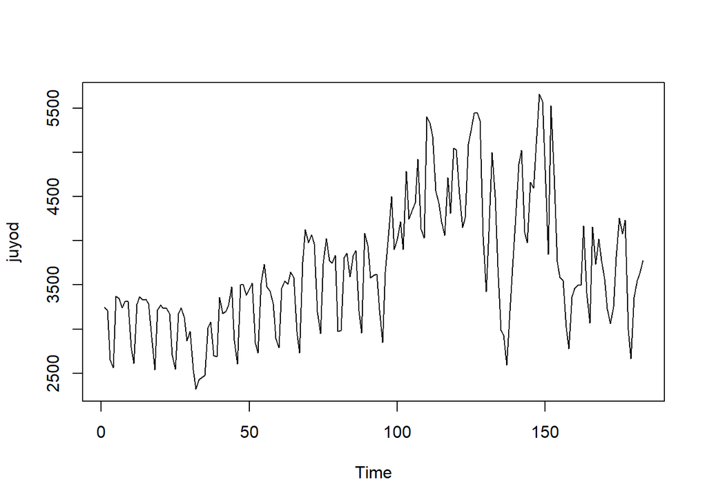

```r
d <- seq.int(from = 15, by = 24, length.out = 183) # 14:00 の位置
juyod <- juyo$elec[d] # 14:00 の電力
tempm <- temp$max # 最高気温
ts.plot(juyod) # 電力の時系列プロット
```

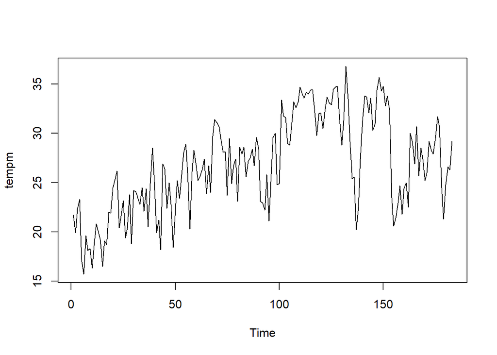

```r
ts.plot(tempm) # 気温の時系列プロット
```

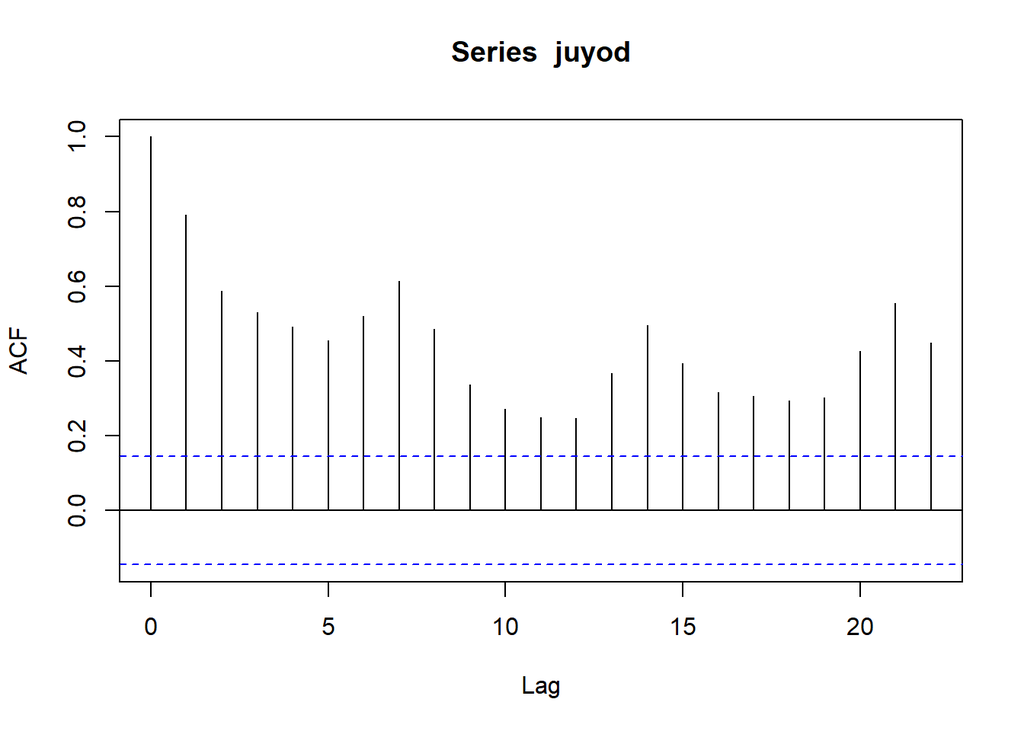

```r
acf(juyod) # 電力のコレログラム
```

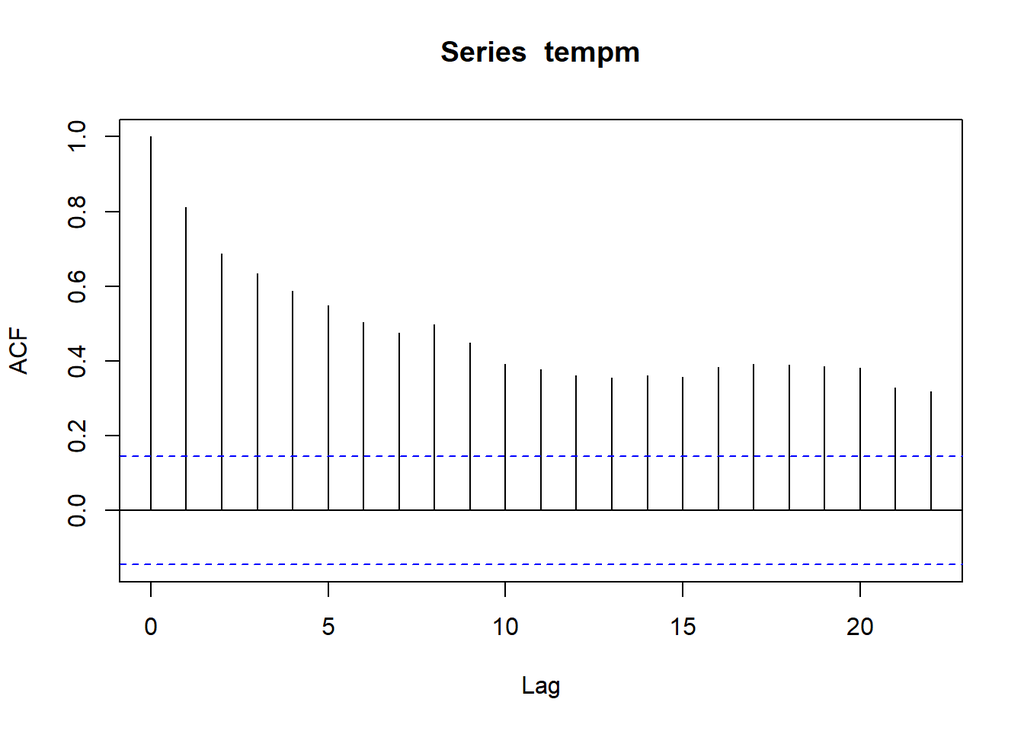

```r
acf(tempm) # 気温のコレログラム
```

```r
elec <- cbind(juyod, tempm, temp[,6:7]) # データの結合
names(elec) <- c("elec", "temp","sat", "sun") # 名称の変更
head(elec)
```

```
##   elec temp sat sun
## 1 3246 21.7   0   0
## 2 3213 19.9   0   0
## 3 2654 22.3   1   0
## 4 2566 23.3   0   1
## 5 3370 17.2   0   0
## 6 3351 15.7   0   0
```

## 2.3 回帰分析

### 2.3.1 LS

```r
M1 <- lm(elec ~ ., data = elec) # 回帰分析
summary(M1) # 結果
```

```
##
## Call:
## lm(formula = elec ~ ., data = elec)
##
## Residuals:
##      Min       1Q   Median       3Q      Max
## -1156.36  -235.08   -22.16   216.88   812.88
##
## Coefficients:
##             Estimate Std. Error t value Pr(>|t|)
## (Intercept)  698.671    149.645   4.669 5.92e-06 ***
## temp         119.008      5.477  21.728  < 2e-16 ***
## sat         -593.280     77.294  -7.676 1.03e-12 ***
## sun         -810.302     77.292 -10.484  < 2e-16 ***
## ---
## Signif. codes:  0 '***' 0.001 '**' 0.01 '*' 0.05 '.' 0.1 ' ' 1
##
## Residual standard error: 360 on 179 degrees of freedom
## Multiple R-squared:  0.7754, Adjusted R-squared:  0.7717
## F-statistic:   206 on 3 and 179 DF,  p-value: < 2.2e-16
```

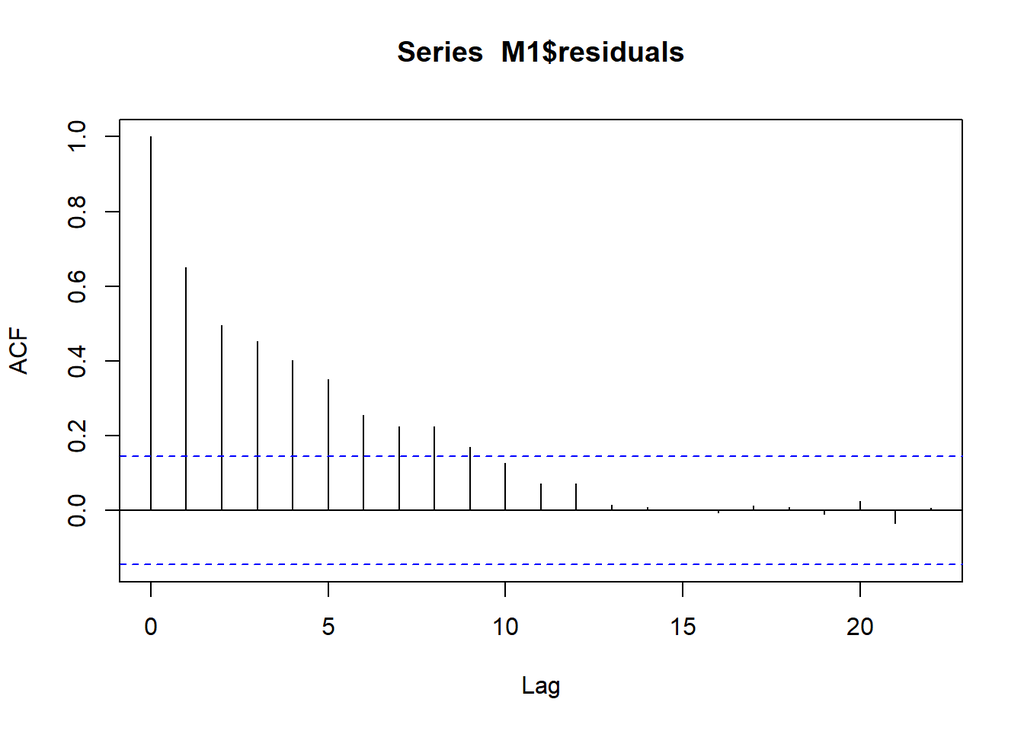

```r
acf(M1$residuals) # 残差のコレログラム
```

```r
ar(M1$residuals)$aic # 残差の AIC
```

```
##          0          1          2          3          4          5          6
## 101.811576   3.545203   2.592339   0.000000   1.301144   3.143101   4.076422
##          7          8          9         10         11         12         13
##   5.938027   7.510878   9.208138  11.135787  12.405770  14.234403  14.844974
##         14         15         16         17         18         19         20
##  16.515458  18.488999  20.458266  22.187340  24.178816  26.041941  27.346122
##         21         22
##  27.089902  27.655280
```

```r
bgtest(M1, order = 3) # Breusch–Godfrey test
```

```
##
##  Breusch-Godfrey test for serial correlation of order up to 3
##
## data:  M1
## LM test = 84.273, df = 3, p-value < 2.2e-16
```

```r
coeftest(M1, vcov = vcovHAC) # HAC estimator
```

```
##
## t test of coefficients:
##
##             Estimate Std. Error  t value  Pr(>|t|)
## (Intercept)  698.671    407.593   1.7141   0.08823 .
## temp         119.008     15.278   7.7896  5.25e-13 ***
## sat         -593.280     47.956 -12.3714 < 2.2e-16 ***
## sun         -810.302     51.580 -15.7097 < 2.2e-16 ***
## ---
## Signif. codes:  0 '***' 0.001 '**' 0.01 '*' 0.05 '.' 0.1 ' ' 1
```

### 2.3.2 FGLS

```r
M1f <- gls(elec ~ ., data = elec, correlation = corARMA(p = 3))
summary(M1f)
```

```
## Generalized least squares fit by REML
##   Model: elec ~ .
##   Data: elec
##       AIC      BIC   logLik
##   2493.08 2518.579 -1238.54
##
## Correlation Structure: ARMA(3,0)
##  Formula: ~1
##  Parameter estimate(s):
##        Phi1        Phi2        Phi3
##  0.75263889 -0.03498133  0.17102781
##
## Coefficients:
##                 Value Std.Error    t-value p-value
## (Intercept) 2029.0121 221.04765   9.179071       0
## temp          68.0252   6.22297  10.931296       0
## sat         -584.8241  41.71832 -14.018400       0
## sun         -800.2196  41.69151 -19.193828       0
##
##  Correlation:
##      (Intr) temp   sat
## temp -0.747
## sat  -0.021 -0.021
## sun  -0.037  0.000  0.493
##
## Standardized residuals:
##         Min          Q1         Med          Q3         Max
## -2.72578493 -0.50575673 -0.09307141  0.50692013  2.68635418
##
## Residual standard error: 454.0448
## Degrees of freedom: 183 total; 179 residual
```